# Untitled

2024-02-28

```r
# Setting the working directory to where the file is located
setwd("C:/Users/patri/OneDrive/Documents/R")
```

```r
# Loading the .RData file into R session
load("C:/Users/patri/OneDrive/Documents/R/AirBnB.RData")
```

```r
file.exists("C:/Users/patri/OneDrive/Documents/R/AirBnB.RData")
```

```
## [1] TRUE
```

```r
# To view contents of the file
ls()
```

```
## [1] "L" "R"
```

```r
# L and R are the AirBnB files after exploring all the rest
```

```r
head(L)
```

```
##         id                           listing_url   scrape_id last_scraped
## 1  4867396  https://www.airbnb.com/rooms/4867396 2.01607e+13   2016-07-03
## 2  7704653  https://www.airbnb.com/rooms/7704653 2.01607e+13   2016-07-04
## 3  2725029  https://www.airbnb.com/rooms/2725029 2.01607e+13   2016-07-04
## 4  9337509  https://www.airbnb.com/rooms/9337509 2.01607e+13   2016-07-03
## 5 12928158 https://www.airbnb.com/rooms/12928158 2.01607e+13   2016-07-04
## 6  5589471  https://www.airbnb.com/rooms/5589471 2.01607e+13   2016-07-04
##                                        name
## 1       Appartement 60m2 Rue Legendre 75017
## 2       Appart au pied de l'arc de triomphe
## 3            Nice appartment in Batignolles
## 4            Charming flat near Batignolles
## 5 Spacious bedroom near the centre of Paris
## 6           Rare, Maison individuelle 200m2
##                                                                                                                                                                                                                                                  summary
```

[output cut: 230 more lines]

```r
head(R)
```

```
##   listing_id       date
## 1   12007141 2016-04-16
## 2   12007141 2016-04-26
## 3   12007141 2016-05-03
## 4   12007141 2016-06-15
## 5    6666099 2015-06-21
## 6    6666099 2015-07-27
```

```r
#install.packages("tidyverse")

library(tidyverse)
#install.packages("dplyr")
#install.packages("tidyr")
#install.packages("strignr")
#install.packages("lubridate")
#install.packages("stats")
```

```r
library(dplyr)
library(stats)
library(tidyr)
library(stringr)
library(lubridate)
```

```r
#join the 2 dataframes L and R "id" in df L is "listing_id" in df R
df1 <- L %>%
  full_join(R, by = c("id" = "listing_id"))
head(df1)
```

```
##         id                           listing_url   scrape_id last_scraped
## 1  4867396  https://www.airbnb.com/rooms/4867396 2.01607e+13   2016-07-03
## 2  7704653  https://www.airbnb.com/rooms/7704653 2.01607e+13   2016-07-04
## 3  2725029  https://www.airbnb.com/rooms/2725029 2.01607e+13   2016-07-04
## 4  9337509  https://www.airbnb.com/rooms/9337509 2.01607e+13   2016-07-03
## 5 12928158 https://www.airbnb.com/rooms/12928158 2.01607e+13   2016-07-04
## 6 12928158 https://www.airbnb.com/rooms/12928158 2.01607e+13   2016-07-04
##                                        name
## 1       Appartement 60m2 Rue Legendre 75017
## 2       Appart au pied de l'arc de triomphe
## 3            Nice appartment in Batignolles
## 4            Charming flat near Batignolles
## 5 Spacious bedroom near the centre of Paris
## 6 Spacious bedroom near the centre of Paris
##                                                                                                                                                                                                                                                  summary
```

[output cut: 230 more lines]

```r
nrow(L)
```

```
## [1] 52725
```

```r
ncol(L)
```

```
## [1] 95
```

```r
nrow(R)
```

```
## [1] 663599
```

```r
ncol(R)
```

```
## [1] 2
```

```r
# the new df has slightly more rows after full join

nrow(df1)
```

```
## [1] 678107
```

```r
ncol(df1)
```

```
## [1] 96
```

```r
# Get the column headers of the data frame L
# Extract the column headers from the data frame L
column_headers <- names(L)

# Print the column headers to the console
print(column_headers)
```

```
##  [1] "id"                               "listing_url"
##  [3] "scrape_id"                        "last_scraped"
##  [5] "name"                             "summary"
##  [7] "space"                            "description"
##  [9] "experiences_offered"              "neighborhood_overview"
## [11] "notes"                            "transit"
## [13] "access"                           "interaction"
## [15] "house_rules"                      "thumbnail_url"
## [17] "medium_url"                       "picture_url"
## [19] "xl_picture_url"                   "host_id"
## [21] "host_url"                         "host_name"
## [23] "host_since"                       "host_location"
## [25] "host_about"                       "host_response_time"
## [27] "host_response_rate"               "host_acceptance_rate"
## [29] "host_is_superhost"                "host_thumbnail_url"
```

[output cut: 33 more lines]

```r
###summary(L)
```

```r
# See the structure of the dataset
dim(L)
```

```
## [1] 52725    95
```

```r
##create a new data frame based on columns of interest for Relationship between prices and apartment features:
#install.packages(c("ggplot2", "corrplot"))
# Load the necessary libraries for analysis and plotting subsequently
library(corrplot)
library(ggplot2)
```

```r
df2 <- df1[c("id", "host_response_time", "state", "beds", "amenities", "bathrooms", "room_type", "price", "monthly_price", "cleaning_fee", "review_scores_rating", "require_guest_profile_picture", "instant_bookable", "security_deposit", "weekly_price", "square_feet", "accommodates", "latitude", "longitude", "zipcode", "neighbourhood_cleansed", "host_has_profile_pic", "city", "minimum_nights", "maximum_nights" , "host_id" , "host_name" , "reviews_per_month" , "first_review" , "last_review")]

head(df2)
```

```
##         id host_response_time         state beds
## 1  4867396                N/A Île-de-France    1
## 2  7704653                N/A Île-de-France    3
## 3  2725029     within an hour Île-de-France    1
## 4  9337509       within a day Île-de-France    1
## 5 12928158     within an hour Île-de-France    1
## 6 12928158     within an hour Île-de-France    1
##                                                                                                                                                       amenities
## 1                                                                          {TV,"Cable TV",Internet,"Wireless Internet",Kitchen,Heating,Washer,Dryer,Essentials}
## 2                                                       {"Wireless Internet",Kitchen,"Elevator in Building","Buzzer/Wireless Intercom",Washer,Dryer,Essentials}
## 3                                          {TV,Internet,"Wireless Internet",Kitchen,"Indoor Fireplace",Heating,"Family/Kid Friendly",Washer,Essentials,Shampoo}
## 4                                                                                                       {"Wireless Internet",Kitchen,Heating,Washer,Essentials}
## 5 {"Wireless Internet",Kitchen,"Smoking Allowed","Pets Allowed",Breakfast,"Elevator in Building",Heating,"Family/Kid Friendly",Washer,Dryer,Essentials,Shampoo}
## 6 {"Wireless Internet",Kitchen,"Smoking Allowed","Pets Allowed",Breakfast,"Elevator in Building",Heating,"Family/Kid Friendly",Washer,Dryer,Essentials,Shampoo}
##   bathrooms       room_type   price monthly_price cleaning_fee
```

[output cut: 34 more lines]

```r
nrow(df2)
```

```
## [1] 678107
```

```r
# conduct Exploratory Summary statistics on the data set
get_mode <- function(v) {
  uniqv <- unique(v)
  uniqv[which.max(tabulate(match(v, uniqv)))]
}

# List of columns to clean and convert
columns_to_convert <- c("price", "monthly_price", "cleaning_fee", "security_deposit", "weekly_price")

# Loop through each column, clean, and convert to numeric
for (col in columns_to_convert) {
    df2[[col]] <- as.numeric(gsub("[\\$,]", "", df2[[col]]))
}

# Ensure that NA values are properly handled and calculate summary statistics
summary_table <- df2 %>%
  summarise(
    Mean_Price = mean(price, na.rm = TRUE),
    Median_Price = median(price, na.rm = TRUE),
    Mode_Price = get_mode(price),
    Range_Price = max(price, na.rm = TRUE) - min(price, na.rm = TRUE),

    Mean_Monthly_Price = mean(monthly_price, na.rm = TRUE),
    Median_Monthly_Price = median(monthly_price, na.rm = TRUE),
    Mode_Monthly_Price = get_mode(monthly_price),
    Range_Monthly_Price = max(monthly_price, na.rm = TRUE) - min(monthly_price, na.rm = TRUE),

    Mean_Cleaning_Fee = mean(cleaning_fee, na.rm = TRUE),
    Median_Cleaning_Fee = median(cleaning_fee, na.rm = TRUE),
    Mode_Cleaning_Fee = get_mode(cleaning_fee),
    Range_Cleaning_Fee = max(cleaning_fee, na.rm = TRUE) - min(cleaning_fee, na.rm = TRUE),

    Mean_Security_Deposit = mean(security_deposit, na.rm = TRUE),
    Median_Security_Deposit = median(security_deposit, na.rm = TRUE),
    Mode_Security_Deposit = get_mode(security_deposit),
    Range_Security_Deposit = max(security_deposit, na.rm = TRUE) - min(security_deposit, na.rm = TRUE),

    Mean_Weekly_Price = mean(weekly_price, na.rm = TRUE),
    Median_Weekly_Price = median(weekly_price, na.rm = TRUE),
    Mode_Weekly_Price = get_mode(weekly_price),
    Range_Weekly_Price = max(weekly_price, na.rm = TRUE) - min(weekly_price, na.rm = TRUE),

    Mean_Square_Feet = mean(square_feet, na.rm = TRUE),
    Median_Square_Feet = median(square_feet, na.rm = TRUE),
    Mode_Square_Feet = get_mode(square_feet),
    Range_Square_Feet = max(square_feet, na.rm = TRUE) - min(square_feet, na.rm = TRUE),

    Mean_Accommodates = mean(accommodates, na.rm = TRUE),
    Median_Accommodates = median(accommodates, na.rm = TRUE),
    Mode_Accommodates = get_mode(accommodates),
    Range_Accommodates = max(accommodates, na.rm = TRUE) - min(accommodates, na.rm = TRUE)
  )

# Display the summary table with the statistics calculated above
print(summary_table)
```

```
##   Mean_Price Median_Price Mode_Price Range_Price Mean_Monthly_Price
## 1   94.79359           79         70        6081           2173.102
##   Median_Monthly_Price Mode_Monthly_Price Range_Monthly_Price Mean_Cleaning_Fee
## 1                 1903                 NA               49739          34.61982
##   Median_Cleaning_Fee Mode_Cleaning_Fee Range_Cleaning_Fee
## 1                  30                NA                747
##   Mean_Security_Deposit Median_Security_Deposit Mode_Security_Deposit
## 1              337.8565                     301                    NA
##   Range_Security_Deposit Mean_Weekly_Price Median_Weekly_Price
## 1                   5942          631.4089                 541
##   Mode_Weekly_Price Range_Weekly_Price Mean_Square_Feet Median_Square_Feet
## 1                NA              13129         289.5791                237
##   Mode_Square_Feet Range_Square_Feet Mean_Accommodates Median_Accommodates
## 1               NA             15059          3.073906                   2
##   Mode_Accommodates Range_Accommodates
## 1                 2                 15
```

```r
# Selecting only the numeric columns relevant for correlation analysis to be performed
# Ensure all these columns are correctly formatted as numeric and contain no NA values
numeric_data <- df2 %>%
  select(price, beds, bathrooms, monthly_price, cleaning_fee, security_deposit, weekly_price, square_feet, accommodates) %>%
  na.omit()  #  This is to ensure removal of all rows with NA values

# Calculate Pearson Correlation Matrix
pearson_correlation_matrix <- cor(numeric_data, method = "pearson")
print("Pearson Correlation Matrix:")
```

```
## [1] "Pearson Correlation Matrix:"
```

```r
print(pearson_correlation_matrix)
```

```
##                      price      beds bathrooms monthly_price cleaning_fee
## price            1.0000000 0.5490161 0.5716710     0.8724167    0.5719399
## beds             0.5490161 1.0000000 0.3906109     0.4804534    0.3932952
## bathrooms        0.5716710 0.3906109 1.0000000     0.5088503    0.3453208
## monthly_price    0.8724167 0.4804534 0.5088503     1.0000000    0.5985937
## cleaning_fee     0.5719399 0.3932952 0.3453208     0.5985937    1.0000000
## security_deposit 0.4935529 0.3208682 0.2866004     0.4504560    0.4007516
## weekly_price     0.9271688 0.5317022 0.5892800     0.9418335    0.5896918
## square_feet      0.5538988 0.4788902 0.4151605     0.5023976    0.4018895
## accommodates     0.6347423 0.8261685 0.4694797     0.5925407    0.4730803
##                  security_deposit weekly_price square_feet accommodates
## price                   0.4935529    0.9271688   0.5538988    0.6347423
## beds                    0.3208682    0.5317022   0.4788902    0.8261685
## bathrooms               0.2866004    0.5892800   0.4151605    0.4694797
## monthly_price           0.4504560    0.9418335   0.5023976    0.5925407
## cleaning_fee            0.4007516    0.5896918   0.4018895    0.4730803
## security_deposit        1.0000000    0.4799527   0.3627772    0.3029387
## weekly_price            0.4799527    1.0000000   0.5207554    0.6162523
## square_feet             0.3627772    0.5207554   1.0000000    0.5151567
## accommodates            0.3029387    0.6162523   0.5151567    1.0000000
```

```r
# Calculate Spearman Correlation Matrix
spearman_correlation_matrix <- cor(numeric_data, method = "spearman")
print("Spearman Correlation Matrix:")
```

```
## [1] "Spearman Correlation Matrix:"
```

```r
print(spearman_correlation_matrix)
```

```
##                      price      beds bathrooms monthly_price cleaning_fee
## price            1.0000000 0.4882039 0.3534344     0.8561154    0.6274164
## beds             0.4882039 1.0000000 0.2747840     0.4345253    0.3578407
## bathrooms        0.3534344 0.2747840 1.0000000     0.3557584    0.3346586
## monthly_price    0.8561154 0.4345253 0.3557584     1.0000000    0.6295379
## cleaning_fee     0.6274164 0.3578407 0.3346586     0.6295379    1.0000000
## security_deposit 0.5055906 0.2441017 0.2010053     0.4175141    0.4414522
## weekly_price     0.9048129 0.4663378 0.3450865     0.9396710    0.6472231
## square_feet      0.4373412 0.2929655 0.2510644     0.4111704    0.3572026
## accommodates     0.5640005 0.7859500 0.3459231     0.5608058    0.4600596
##                  security_deposit weekly_price square_feet accommodates
## price                   0.5055906    0.9048129   0.4373412    0.5640005
## beds                    0.2441017    0.4663378   0.2929655    0.7859500
## bathrooms               0.2010053    0.3450865   0.2510644    0.3459231
## monthly_price           0.4175141    0.9396710   0.4111704    0.5608058
## cleaning_fee            0.4414522    0.6472231   0.3572026    0.4600596
## security_deposit        1.0000000    0.4711227   0.2743258    0.2160397
## weekly_price            0.4711227    1.0000000   0.3944743    0.5534436
## square_feet             0.2743258    0.3944743   1.0000000    0.3701771
## accommodates            0.2160397    0.5534436   0.3701771    1.0000000
```

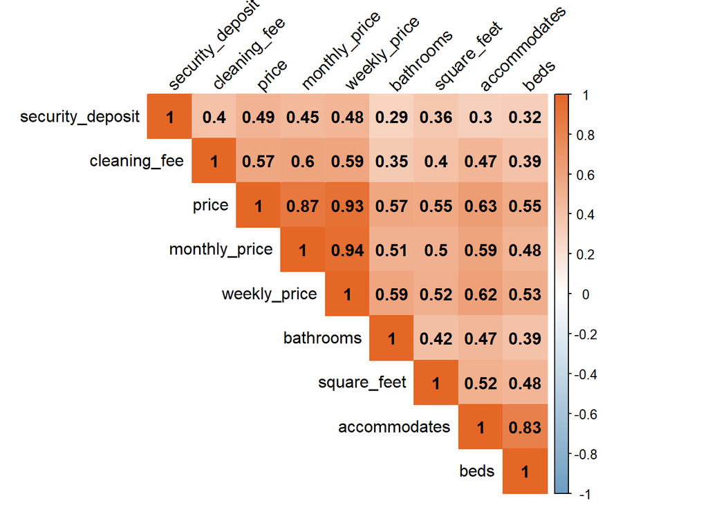

```r
# Selecting the numeric columns for correlation analysis

numeric_df <- df2 %>% select(price, monthly_price, cleaning_fee, security_deposit, weekly_price, square_feet, accommodates, beds, bathrooms)

# Compute the correlation matrix & Use methods "pearson" for Pearson's correlation or "spearman" for Spearman's correlation
corr_matrix <- cor(numeric_df, use = "complete.obs", method = "pearson") #ensures that only complete cases are used in the calculation. (observations with non-missing values for all variables being considered)

# Plot the heatmap of the correlation matrix
corrplot(corr_matrix, type = "upper", order = "hclust",
         tl.col = "black", tl.srt = 45,
         method = "color", addCoef.col = "black",
         # generating the colours for the heatmap
         col = colorRampPalette(c("#6D9EC1", "white", "#E46726"))(200))
```

> Remarks: Pearson Correlation Matrix Interpretation: Price Relationships: The price is strongly correlated with monthly_price (0.872) and weekly_price (0.927), indicating that listings with higher regular prices tend to have higher monthly and weekly rates. This is expected as these variables are directly related to the overall cost of renting. Space and Accommodation: There’s a significant positive correlation between price and accommodates (0.635), beds (0.549), and bathrooms (0.572). This suggests that larger apartments (more beds, space, or bathrooms) tend to have higher rental prices. Cleaning Fee: The cleaning_fee shows a moderate correlation with price (0.572), suggesting that higher-priced listings may have higher cleaning fees. Square Feet: Square_feet is moderately correlated with price (0.554), indicating that larger apartments tend to be priced higher, which aligns with typical real estate valuation based on size. Spearman Correlation Matrix Interpretation: Price and Rental Rates: Similar to the Pearson results, price has strong correlations with monthly_price (0.856) and weekly_price (0.905), reaffirming that higher prices correlate with higher long-term rental rates. Cleaning Fee: The correlation between cleaning_fee and price is stronger here (0.627) compared to Pearson’s, indicating that when ranking listings from cheapest to most expensive, those with higher cleaning fees generally are priced higher. Accommodates: The correlation between price and accommodates (0.564) is slightly lower than Pearson’s but still significant, reinforcing the relationship between the capacity of an apartment and its price. Less Influence of Beds and Bathrooms: The Spearman correlations for beds (0.488) and bathrooms (0.353) with price are lower than Pearson’s, suggesting that while there is a relationship, the rank order of prices is less directly tied to the number of beds and bathrooms compared to the linear relationship suggested by Pearson. Overall Deductions: Both correlation matrices highlight strong relationships between price and the variables related to the size and capacity of listings (e.g., accommodates, square_feet). The cleaning fee, security deposit, and other costs associated with renting are also correlated with price, but to varying degrees. The differences between Pearson and Spearman correlations suggest that while some relationships are linear (Pearson), others might be more about the rank order or non-linear relationships (Spearman).

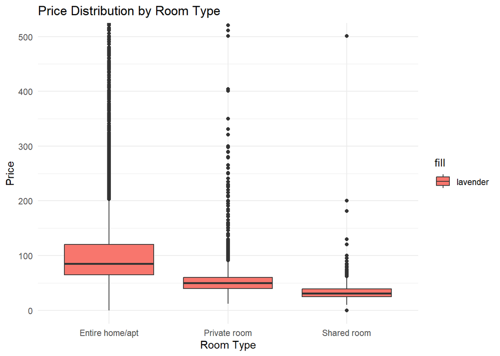

```r
# Create the box plot to show price distribution by room type. using price upto 500 since the outliers are many resulting in overplotting
ggplot(data = df2, aes(x = room_type, y = price ,fill='lavender')) +
  geom_boxplot() +
  labs(title = "Price Distribution by Room Type", x = "Room Type", y = "Price") +
  theme_minimal() +
  coord_cartesian(ylim = c(0, 500))
```

> Remark: As expected, renting an entire home costs more than private room and least for a shared room. There are however there are still many data points above the 75% percentile or 3rd Quartile.

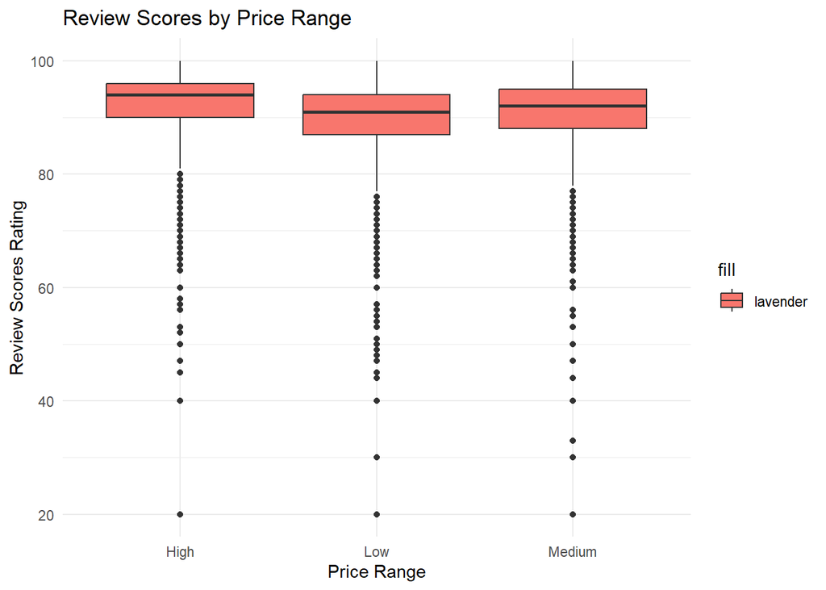

```r
#creating a box plot comparing review scores across different price ranges. Categorizing the price into ranges (low, medium, high).

# Calculate price thresholds for categories based on quartiles initially
low_price_threshold <- quantile(df2$price, 0.33, na.rm = TRUE)
high_price_threshold <- quantile(df2$price, 0.66, na.rm = TRUE)

# then categorize price into Low, Medium, High for ease of classification
df2 <- df2 %>%
  mutate(price_category = case_when(
    price <= low_price_threshold ~ "Low",
    price > low_price_threshold & price <= high_price_threshold ~ "Medium",
    price > high_price_threshold ~ "High",
    TRUE ~ NA_character_  # For missing values
  ))

# Creating a box plot for visualization
ggplot(data = df2, aes(x = price_category, y = review_scores_rating, fill='lavender')) +
  geom_boxplot() +
  labs(title = "Review Scores by Price Range", x = "Price Range", y = "Review Scores Rating") +
  theme_minimal()
```

> Remark: properties with high review scores tend to be those with higher prices reflecting possibly higher standards.

```r
# To use features for showing relationship between price and other variables. Here define the dataset and features
features <- c("beds", "bathrooms", "monthly_price", "cleaning_fee", "security_deposit", "weekly_price", "square_feet", "accommodates")
```

```
##
## Call:
## lm(formula = formula, data = df2)
##
## Residuals:
##    Min     1Q Median     3Q    Max
## -575.4  -26.3   -9.3   17.7 6009.7
##
## Coefficients:
##             Estimate Std. Error t value Pr(>|t|)
## (Intercept) 36.18398    0.13471   268.6   <2e-16 ***
## beds        35.07899    0.06842   512.7   <2e-16 ***
## ---
## Signif. codes:  0 '***' 0.001 '**' 0.01 '*' 0.05 '.' 0.1 ' ' 1
##
## Residual standard error: 58.59 on 677257 degrees of freedom
##   (848 observations deleted due to missingness)
## Multiple R-squared:  0.2796, Adjusted R-squared:  0.2796
## F-statistic: 2.629e+05 on 1 and 677257 DF,  p-value: < 2.2e-16
```

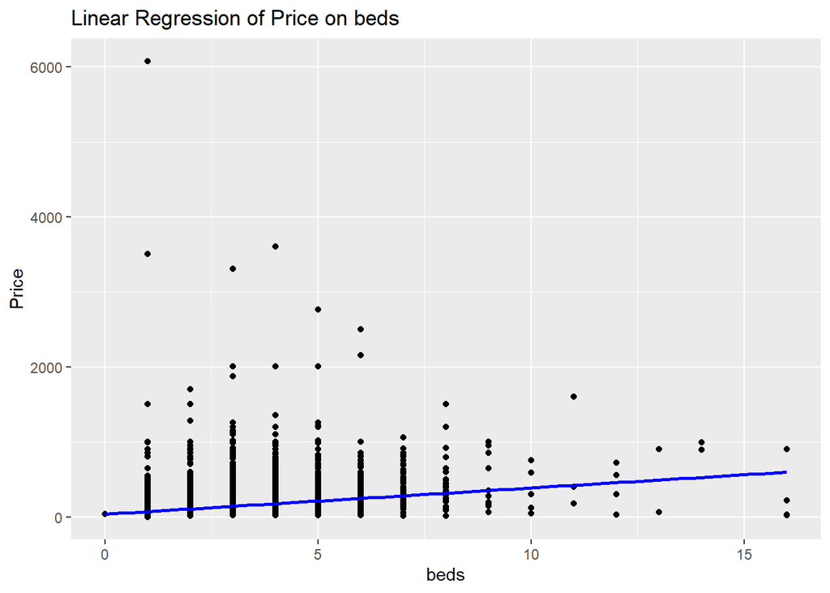

```
##
## Call:
## lm(formula = formula, data = df2)
##
## Residuals:
##    Min     1Q Median     3Q    Max
## -615.3  -32.7   -9.7   16.3 6032.7
##
## Coefficients:
##             Estimate Std. Error t value Pr(>|t|)
## (Intercept)   7.7932     0.2392   32.58   <2e-16 ***
## bathrooms    80.9362     0.2108  383.99   <2e-16 ***
## ---
## Signif. codes:  0 '***' 0.001 '**' 0.01 '*' 0.05 '.' 0.1 ' ' 1
##
## Residual standard error: 62.66 on 672673 degrees of freedom
##   (5432 observations deleted due to missingness)
## Multiple R-squared:  0.1798, Adjusted R-squared:  0.1798
## F-statistic: 1.474e+05 on 1 and 672673 DF,  p-value: < 2.2e-16
```

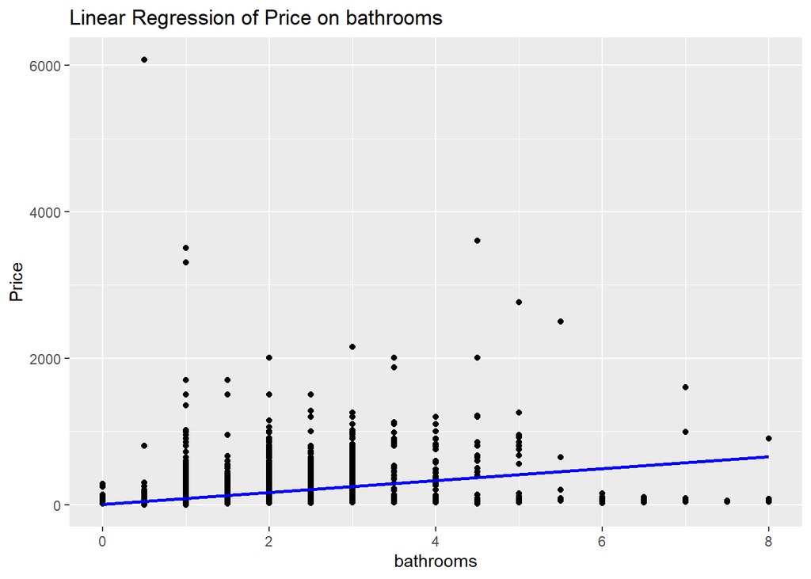

```
##
## Call:
## lm(formula = formula, data = df2)
##
## Residuals:
##     Min      1Q  Median      3Q     Max
## -622.38  -11.87   -1.47   10.06 1626.24
##
## Coefficients:
##                Estimate Std. Error t value Pr(>|t|)
## (Intercept)   6.7188181  0.1083717    62.0   <2e-16 ***
## monthly_price 0.0411261  0.0000425   967.6   <2e-16 ***
## ---
## Signif. codes:  0 '***' 0.001 '**' 0.01 '*' 0.05 '.' 0.1 ' ' 1
##
## Residual standard error: 30.94 on 297973 degrees of freedom
##   (380132 observations deleted due to missingness)
## Multiple R-squared:  0.7586, Adjusted R-squared:  0.7586
## F-statistic: 9.363e+05 on 1 and 297973 DF,  p-value: < 2.2e-16
```

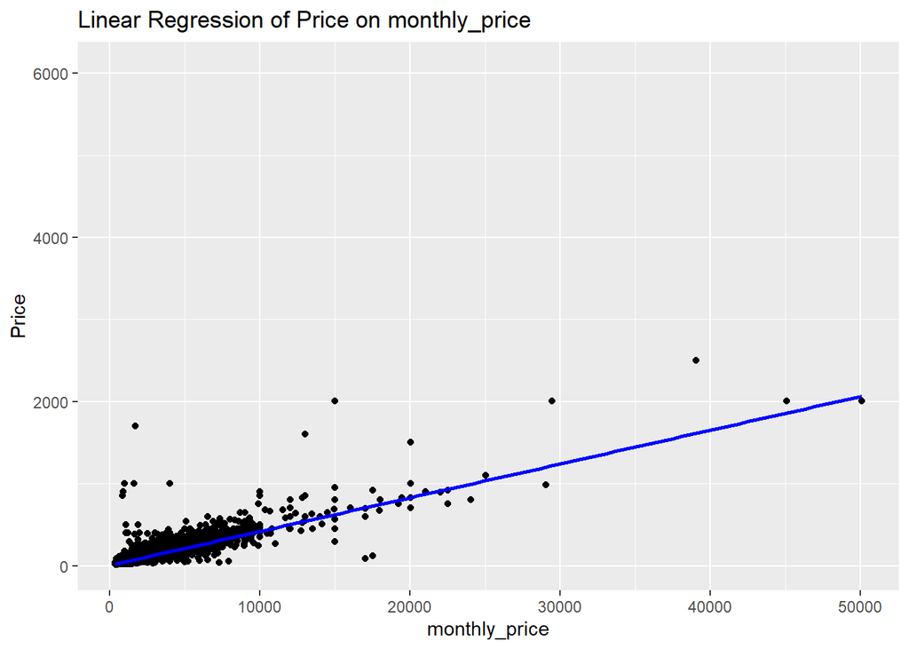

```
##
## Call:
## lm(formula = formula, data = df2)
##
## Residuals:
##     Min      1Q  Median      3Q     Max
## -820.02  -25.62   -5.92   16.96 1647.42
##
## Coefficients:
##              Estimate Std. Error t value Pr(>|t|)
## (Intercept)  31.51530    0.13878   227.1   <2e-16 ***
## cleaning_fee  1.97008    0.00332   593.4   <2e-16 ***
## ---
## Signif. codes:  0 '***' 0.001 '**' 0.01 '*' 0.05 '.' 0.1 ' ' 1
##
## Residual standard error: 53.49 on 472805 degrees of freedom
##   (205300 observations deleted due to missingness)
## Multiple R-squared:  0.4268, Adjusted R-squared:  0.4268
## F-statistic: 3.521e+05 on 1 and 472805 DF,  p-value: < 2.2e-16
```

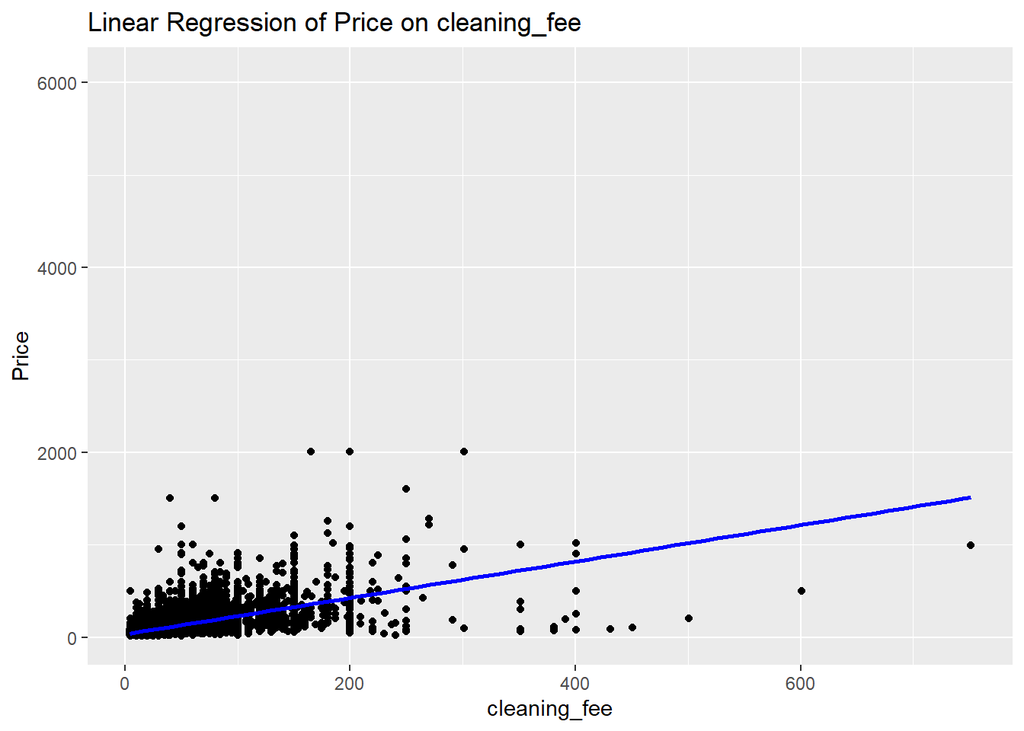

```
##
## Call:
## lm(formula = formula, data = df2)
##
## Residuals:
##     Min      1Q  Median      3Q     Max
## -616.65  -30.91  -10.91   17.09 1838.51
##
## Coefficients:
##                   Estimate Std. Error t value Pr(>|t|)
## (Intercept)      5.869e+01  1.470e-01   399.2   <2e-16 ***
## security_deposit 1.289e-01  3.355e-04   384.2   <2e-16 ***
## ---
## Signif. codes:  0 '***' 0.001 '**' 0.01 '*' 0.05 '.' 0.1 ' ' 1
##
## Residual standard error: 64.33 on 471841 degrees of freedom
##   (206264 observations deleted due to missingness)
## Multiple R-squared:  0.2383, Adjusted R-squared:  0.2383
## F-statistic: 1.476e+05 on 1 and 471841 DF,  p-value: < 2.2e-16
```

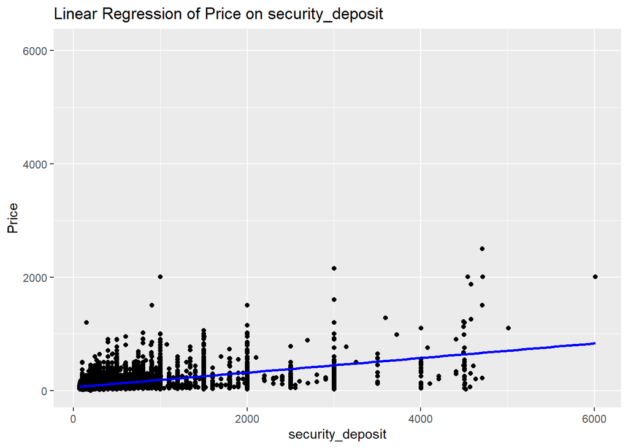

```
##
## Call:
## lm(formula = formula, data = df2)
##
## Residuals:
##     Min      1Q  Median      3Q     Max
## -790.55   -6.63    0.36    6.79 1451.92
##
## Coefficients:
##               Estimate Std. Error t value Pr(>|t|)
## (Intercept)  2.923e+00  7.300e-02   40.05   <2e-16 ***
## weekly_price 1.457e-01  9.752e-05 1494.16   <2e-16 ***
## ---
## Signif. codes:  0 '***' 0.001 '**' 0.01 '*' 0.05 '.' 0.1 ' ' 1
##
## Residual standard error: 24.02 on 375339 degrees of freedom
##   (302766 observations deleted due to missingness)
## Multiple R-squared:  0.8561, Adjusted R-squared:  0.8561
## F-statistic: 2.233e+06 on 1 and 375339 DF,  p-value: < 2.2e-16
```

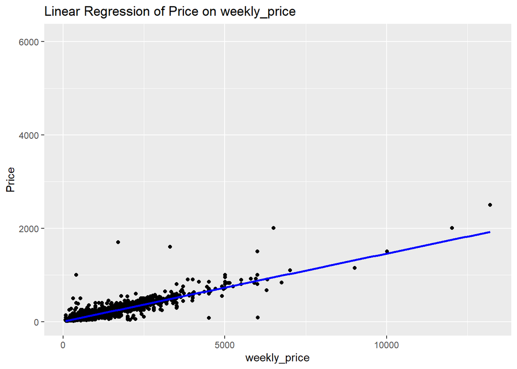

```
##
## Call:
## lm(formula = formula, data = df2)
##
## Residuals:
##      Min       1Q   Median       3Q      Max
## -1510.53   -29.24   -10.90    16.59   758.85
##
## Coefficients:
##              Estimate Std. Error t value Pr(>|t|)
## (Intercept) 7.190e+01  2.254e-01   319.0   <2e-16 ***
## square_feet 9.885e-02  4.944e-04   199.9   <2e-16 ***
## ---
## Signif. codes:  0 '***' 0.001 '**' 0.01 '*' 0.05 '.' 0.1 ' ' 1
##
## Residual standard error: 51.36 on 87036 degrees of freedom
##   (591069 observations deleted due to missingness)
## Multiple R-squared:  0.3147, Adjusted R-squared:  0.3147
## F-statistic: 3.997e+04 on 1 and 87036 DF,  p-value: < 2.2e-16
```

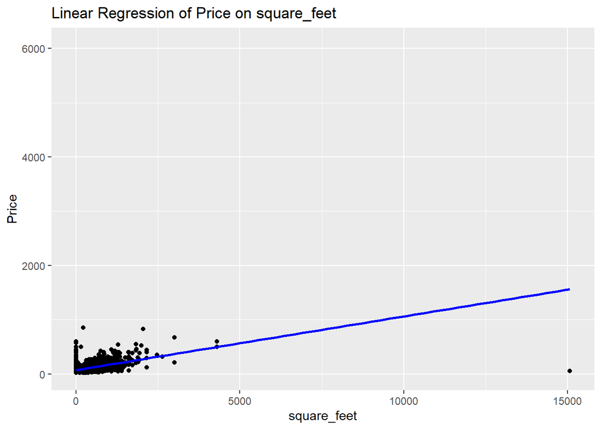

```
##
## Call:
## lm(formula = formula, data = df2)
##
## Residuals:
##    Min     1Q Median     3Q    Max
## -416.1  -25.6   -5.6   14.4 6015.4
##
## Coefficients:
##              Estimate Std. Error t value Pr(>|t|)
## (Intercept)  11.25924    0.15582   72.26   <2e-16 ***
## accommodates 27.17531    0.04563  595.62   <2e-16 ***
## ---
## Signif. codes:  0 '***' 0.001 '**' 0.01 '*' 0.05 '.' 0.1 ' ' 1
##
## Residual standard error: 55.92 on 678105 degrees of freedom
## Multiple R-squared:  0.3435, Adjusted R-squared:  0.3435
## F-statistic: 3.548e+05 on 1 and 678105 DF,  p-value: < 2.2e-16
```

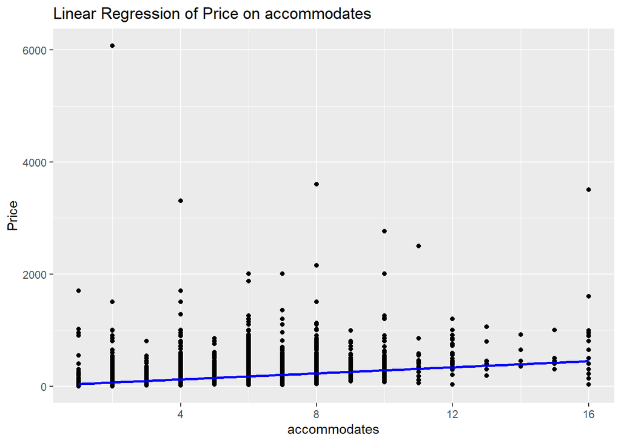

```r
#Regression analysis of selected features of listings against price. Simple Linear Regression for each feature
for (feature in features) {
  formula <- as.formula(paste("price ~", feature))
  model <- lm(formula, data = df2)
  print(summary(model))  # Output the summary of the regression analysis

  # Plotting
  plot <- ggplot(df2, aes_string(x = feature, y = "price")) +
    geom_point() +
    geom_smooth(method = "lm", se = FALSE, color = "blue") +
    labs(title = paste("Linear Regression of Price on", feature), x = feature, y = "Price")
  print(plot)  # Display the plot
}
```

>Remarks: Bathrooms: The model suggests a significant positive relationship between the number of bathrooms and the price. For each additional bathroom, the price increases by approximately 80.94 units. This model explains about 17.98% of the variance in prices.

> Monthly Price: There is a strong positive relationship between monthly price and the original listing price, with a coefficient of 0.0411. This suggests that for each unit increase in monthly price, the listing price increases by approximately the same factor. This relationship is very strong, explaining approximately 75.86% of the variance in prices.

> Cleaning Fee: The cleaning fee also has a significant positive effect on the price, with an increase of about 1.97 units for each unit increase in the cleaning fee. This model accounts for 42.68% of the variance in prices.

> Security Deposit: There’s a positive relationship between security deposit and price, with the price increasing by approximately 0.1289 units for each unit increase in the security deposit. This model explains about 23.83% of the variance in prices.

> Weekly Price: The relationship between weekly price and listing price is very strong, with the listing price increasing by about 0.1457 units for each unit increase in weekly price. This model has an extremely high R-squared value of 85.61%, indicating that weekly price is a very strong predictor of the listing price.

> Square Feet: The size of the property, measured in square feet, also significantly affects the price. Each additional square foot increases the price by approximately 0.0988 units. This model explains 31.47% of the variance in prices.

> Accommodates: The number of people the listing accommodates is a strong predictor of price, with each additional person accommodated increasing the price by about 27.18 units. This model explains about 34.35% of the variance in prices.

> Moderate Predictors: Cleaning fee and square footage also play significant roles in determining price but to a lesser extent compared to the weekly and monthly rates.

> Practical Implications: For hosts or property managers, focusing on what can make listings accommodate more people or setting appropriate cleaning fees could help in optimizing listing prices. Also, for long-term rentals, setting competitive monthly or weekly prices is crucial as they strongly correlate with the listing’s price.

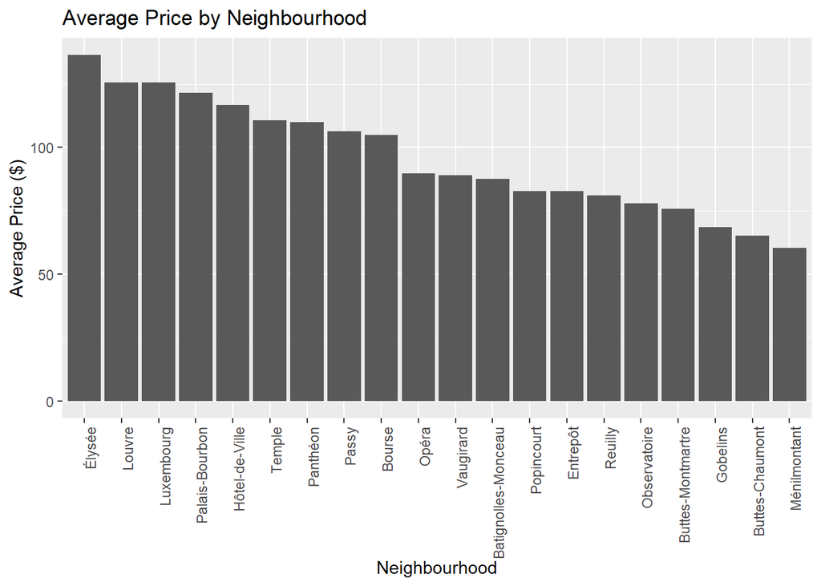

```r
#To investigate the effect of location on price :Renting price per city quarter ("arrondissements"):

# Average, Median Price by Neighbourhood
price_by_neighbourhood <- df2 %>%
  group_by(neighbourhood_cleansed) %>%
  summarise(
    Average_Price = mean(price, na.rm = TRUE),
    Median_Price = median(price, na.rm = TRUE),
    Price_Range = max(price, na.rm = TRUE) - min(price, na.rm = TRUE)
  ) %>%
  arrange(desc(Average_Price))

# Plot
ggplot(price_by_neighbourhood, aes(x = reorder(neighbourhood_cleansed, -Average_Price), y = Average_Price)) +
  geom_bar(stat = "identity") +
  theme(axis.text.x = element_text(angle = 90, hjust = 1)) +
  labs(title = "Average Price by Neighbourhood", x = "Neighbourhood", y = "Average Price ($)")
```

```r
# Investigating the number of apartments per host. Selecting top 10
apartments_per_host <- df2 %>%
  group_by(host_id, host_name) %>%  # Assuming host_id uniquely identifies owners
  summarise(Num_Apartments = n(), .groups = 'drop') %>%
  arrange(desc(Num_Apartments)) %>%
  slice_max(order_by = Num_Apartments, n = 10)  # Consistent top 10 selection
head(apartments_per_host, 10)
```

```
## # A tibble: 10 × 3
##     host_id host_name     Num_Apartments
##       <int> <fct>                  <int>
##  1  2107478 Philippe                1981
##  2   850078 Ludwig                  1448
##  3  3456707 Audrey                  1189
##  4   261483 Patrick                 1012
##  5  3943828 Caroline                1007
##  6    81848 Jean Francois            867
##  7 10447019 Régis                    853
##  8  3524873 Tony                     852
##  9  1466866 Chokri                   838
## 10  2604436 Nicolas                  836
```

```r
nrow(apartments_per_host)
```

```
## [1] 10
```

```r
# Calculat the summary statistics of number of apartments per host
apartments_per_host <- df2 %>%
  group_by(host_id) %>%
  summarise(num_apartments = n_distinct(id), .groups = 'drop')

# Calculate mean, median
mean_apartments = mean(apartments_per_host$num_apartments)
median_apartments = median(apartments_per_host$num_apartments)

# Calculate mode - R does not have a built-in mode function, so we create one
get_mode <- function(v) {
  uniqv <- unique(v)
  uniqv[which.max(tabulate(match(v, uniqv)))]
}
mode_apartments = get_mode(apartments_per_host$num_apartments)

# Print the results
cat("Mean number of apartments per owner: ", mean_apartments, "\n")
```

```
## Mean number of apartments per owner:  1.174957
```

```r
cat("Median number of apartments per owner: ", median_apartments, "\n")
```

```
## Median number of apartments per owner:  1
```

```r
cat("Mode number of apartments per owner: ", mode_apartments, "\n")
```

```
## Mode number of apartments per owner:  1
```

> Remark: Many apartments are single owner. Not many people have multiple apartments in Paris

```r
#Looking at Visit frequency of the different quarters according to time
# Add year, month, and quarter to the dataset along with a formatted year-quarter label. Using last_review as a proxy of when a listing was visited as it is assumed that a review takes place after visiting a listing. There is no column for listings visited in the dataset
df2 <- df2 %>%
   filter(!is.na(ymd(last_review))) %>%  # Exclude rows where last_review is NA
  mutate(
    year = year(ymd(last_review)),  # Extract the year from the last review date as a proxy
    quarter = quarter(ymd(last_review)),  # Extract the quarter from the last review date
    year_quarter = paste(year, "Q", quarter, sep="")  # Create a formatted year-quarter string
  ) %>%
  group_by(year, quarter, year_quarter) %>%
  summarise(
    average_reviews_per_month = mean(reviews_per_month, na.rm = TRUE),
    .groups = 'drop'
  )


# Display the summarized table
print(df2)
```

```
## # A tibble: 24 × 4
##     year quarter year_quarter average_reviews_per_month
##    <dbl>   <int> <chr>                            <dbl>
##  1  2010       2 2010Q2                          0.01
##  2  2010       3 2010Q3                          0.0233
##  3  2011       2 2011Q2                          0.0267
##  4  2011       3 2011Q3                          0.07
##  5  2011       4 2011Q4                          0.157
##  6  2012       1 2012Q1                          0.14
##  7  2012       2 2012Q2                          0.219
##  8  2012       3 2012Q3                          0.221
##  9  2012       4 2012Q4                          0.133
## 10  2013       1 2013Q1                          0.116
## # ℹ 14 more rows
```

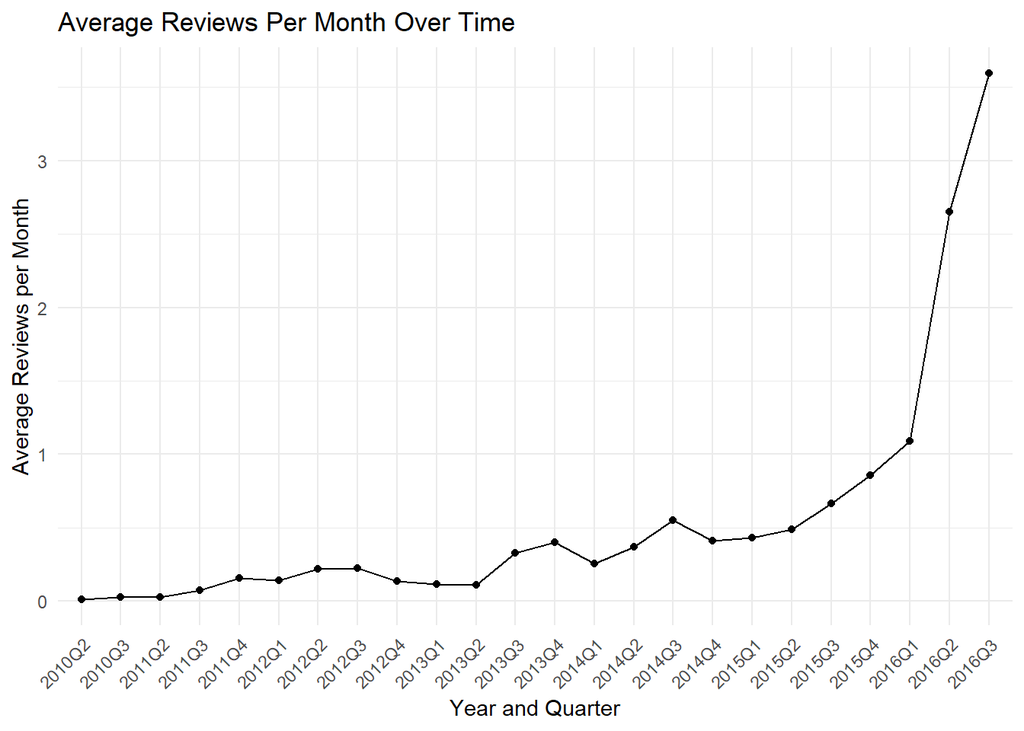

```r
# Plotting the trend over time
ggplot(df2, aes(x = year_quarter, y = average_reviews_per_month)) +
  geom_line(group = 1) +
  geom_point() +
  labs(title = "Average Reviews Per Month Over Time",
       x = "Year and Quarter",
       y = "Average Reviews per Month") +
  theme_minimal() +
  theme(axis.text.x = element_text(angle = 45, hjust = 1))  # Rotate x labels for better readability
```